# Credit Analysis

Mitch Edmunds

10 March 2019

## Introduction

### Overview

This project is an analysis of the [Credit Approval dataset](http://archive.ics.uci.edu/ml/datasets/Credit+Approval) available on the [UCI Machine Learning Repository](http://archive.ics.uci.edu/ml/index.php), and the machine learning algorithms that can be used to build models that predict the classes well. The dataset is built from a collection of credit card applications made to a particular company. Each instance in the dataset has a class label, either approved (+) or denied (-), and so the problem can be defined in machine learning terms as a binary classification problem - a common problem for which there are a variety of techniques available to try.

I’ll be using the [Weka (Waikato Environment for Knowledge Analysis) machine learning workbench](https://www.cs.waikato.ac.nz/ml/weka/index.html) for applying the different learning schemes, and the R programming language for some data preparation and exploratory data analysis. The reason I’m using Weka instead of R for the machine learning is because I want to focus on interpretation and comparison of results, and explore the various stages of the machine learning process without having to get bogged down in debugging code.

### Purpose

The purpose of this project is to practice the applied machine learning process and explore the principles of comparing performance between different learning methods. I’m aiming to demonstrate the following:

- Sound problem definition
- Preparation of data
- Spot-check learning algorithms and performance comparison
- Methods to improve the accuracy

The summary of this analysis is intentionally verbose as I describe my experience of some of these processes for the first time. I will aim for future analyses to be more succinct.

### Background

The decision to approve a loan or credit application tends to be based on the personal and financial background of an applicant. Loans are approved by assessing the risk that a particular applicant is likely to default on the loan or not. Applicants that are not likely to default should be approved.

Credit analysis is important for any company in the business of granting credit, because it can help to reduce the risk of approving applicants that are likely to default on their loans which in turn hurts profits (or in worse cases - generates losses). It is also important for helping to regulate the economy and ensure that consumer credit does not grow to dangerous levels. An extreme case of a lack of oversight and analysis before credit approval is the US Subprime Mortgage Crisis that triggered the global financial crash in 2008.

From prior knowledge, it would be expected that particular attributes such as income, credit history and employment status will be good predictors of an approval decision. We would hope to see that more personal attributes, such as gender, age and ethnicity, would be much less influential to the outcome of an approval decision than the financial attributes, as it would be unethical to discriminate on these grounds. However, sometimes an applicant’s financial position can be correlated with their personal background due to a difference in opportunities, so while it may appear that some approval decisions are biased towards different personal attributes, it may just be on account of the correlation.

### The Problem

At its simplest the problem can be stated as:

*“Given a number of attributes about a loan/credit application, can I predict whether a loan should be approved or not?”*"

If we wanted to formalise the problem according to Tom Mitchell’s definition of Machine Learning:

> “A computer program is said to learn from experience E with respect to some class of tasks T and performance measure P, if its performance at tasks in T, as measured by P, improves with experience E.”

We might reduce it to:

- **Task (T)**: Classify a new loan applicant as approved or not.
- **Evidence (E)**: A set of loan applications where applicants have filled in a number of numeric and non-numeric attributes about their status.
- **Performance (P)**: The classification accuracy. We also want to reduce the false positives as a defaulting customer costs more than profit gained from a missed customer.

## The Data

This section will describe what we can initially learn from the data from its documentation, the method to download and parse into R Studio, and any points of note from the initial exploration.

The dataset used in this analysis is the Credit Approval dataset obtained from the UCI Machine Learning Repository. The UCI Machine Learning Repository is a fantastic repository of more than 450 datasets that are typically already pre-processed to a degree in which they are in a useful format to apply machine learning models. This saves you the hassle of having to clean the data yourself, and enables you to focus on getting to grips with machine learning problems.

We must note however, that most real-world datasets do not land in your lap already pre-processed. They generally require a significant amount of cleaning and wrangling to be ready for machine learning applications (representing the bulk of the work for data scientists). Each dataset available on the UCI Machine Learning Repository is likely the product of many hours of specialists’ time, who had the relevant expertise and domain knowledge to get the data into a clean and workable format.

The credit approval dataset is a collection of credit card applications with the class labels representing whether the application was approved or not. The dataset seems to appear multiple times on UCI, where it is also under the names Japanese Credit Screening and Statlog (Australian Credit Approval), where in the latter the nominal data has been recoded to numerical values “for the convenience of the statistical algorithms”. The original dataset was donated by J. Ross Quinlan, a prominent data mining researcher who developed the landmark decision tree program C4.5. At the time, it appears he held a post at The University of Sydney, which would explain the Aussie link! However, for the purposes of this analysis I have stuck with the original dataset.

The following information is immediately available on the dataset:

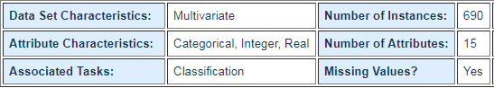

Click on the “Data Folder” link to access the data. You arrive at a repository with a number of files:

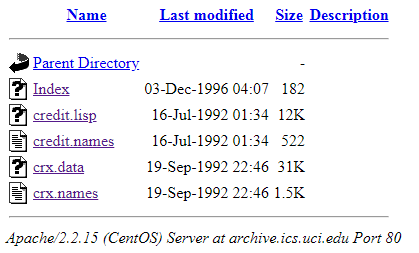

The files of interest are *crx.data* and *crx.names*. The *.data* and *.names* file format is typical of the [C4.5 data format](http://www.cs.washington.edu/dm/vfml/appendixes/c45.htm), but the .names file in this instance isn’t exactly the format we might expect. Instead it contains information about the dataset, most of which was already available to us on the dataset homepage. The only information of further interest might be the class distribution which shows the following:

```
+: 307 (44.5%)
-: 383 (55.5%)
```

If we were to create a test/train split or cross-validation folds for evaluating machine learning models, we’d ideally maintain this distribution.

The *.data* file contains the raw data of interest. Notice that there are no column headings present in the raw data. That’s because the attribute names are stored in the *.names* file (in this case, just *A1, A2, …, A16*). We’ll need to specify this when we load in the data.

### Loading the Data

The data can be downloaded from the internet by specifying the URL of the source *.data* file and passing it to a suitable function for reading CSV files. I’ve used the `read.table()` function and specified the `header` argument to account for the lack of headings present in the data. I’ve also specified the class type for each column using the `colClasses` argument to skip the need to coerce columns later on. This step also improves the speed of the loading function.

```r
# Load packages
library(tidyverse)

# Load in the credit approval data from URL
data.URL <- "http://archive.ics.uci.edu/ml/machine-learning-databases/credit-screening/crx.data"

classes <- c("factor", "double", "double", "factor", "factor", "factor", "factor",
             "double", "character", "character", "integer", "character", "factor",
             "factor", "integer", "factor")

df <- read.table(data.URL,
                 header = FALSE,
                 sep =",",
                 na.strings = "?",
                 colClasses = classes)
df <- as_tibble(df)
```

```r
glimpse(df)
```

```
## Rows: 690
## Columns: 16
## $ V1  <fct> b, a, a, b, b, b, b, a, b, b, b, b, a, b, a, b, b, a, b, a, b, ...
## $ V2  <dbl> 30.83, 58.67, 24.50, 27.83, 20.17, 32.08, 33.17, 22.92, 54.42, ...
## $ V3  <dbl> 0.000, 4.460, 0.500, 1.540, 5.625, 4.000, 1.040, 11.585, 0.500,...
## $ V4  <fct> u, u, u, u, u, u, u, u, y, y, u, u, u, u, u, y, u, u, u, u, u, ...
## $ V5  <fct> g, g, g, g, g, g, g, g, p, p, g, g, g, g, g, p, g, g, g, g, g, ...
## $ V6  <fct> w, q, q, w, w, m, r, cc, k, w, c, c, k, k, q, k, m, q, d, cc, c...
## $ V7  <fct> v, h, h, v, v, v, h, v, h, v, h, h, v, v, v, v, v, v, h, h, v, ...
## $ V8  <dbl> 1.250, 3.040, 1.500, 3.750, 1.710, 2.500, 6.500, 0.040, 3.960, ...
## $ V9  <chr> "t", "t", "t", "t", "t", "t", "t", "t", "t", "t", "f", "t", "t"...
## $ V10 <chr> "t", "t", "f", "t", "f", "f", "f", "f", "f", "f", "f", "f", "f"...
## $ V11 <int> 1, 6, 0, 5, 0, 0, 0, 0, 0, 0, 0, 0, 0, 0, 7, 10, 3, 10, 0, 7, 1...
## $ V12 <chr> "f", "f", "f", "t", "f", "t", "t", "f", "f", "t", "t", "f", "t"...
## $ V13 <fct> g, g, g, g, s, g, g, g, g, g, g, g, g, g, g, g, g, g, g, g, g, ...
## $ V14 <fct> 00202, 00043, 00280, 00100, 00120, 00360, 00164, 00080, 00180, ...
## $ V15 <int> 0, 560, 824, 3, 0, 0, 31285, 1349, 314, 1442, 0, 200, 0, 2690, ...
## $ V16 <fct> +, +, +, +, +, +, +, +, +, +, +, +, +, +, +, +, +, +, +, +, +, ...
```

### Attribute Names

The data was supplied by a confidential source, and to protect the confidentiality of the dataset the attribute names and values have been changed to arbitrary labels. It becomes difficult to derive meaning from the dataset without meaningful labels and so we should give the attributes some working names based on the data[^1].

```r
# Recode the column names
col.names <- c("Gender", "Age", "Debt", "MaritalStatus", "BankCustomer", "EducationLevel", "Ethnicity",
               "YearsEmployed", "NoPriorDefault", "Employed", "CreditScore", "DriversLicense", "Citizen",
               "ZipCode", "Income", "Approved")
names(df) <- col.names

# Glimpse the data
glimpse(df)
```

```
## Rows: 690
## Columns: 16
## $ Gender         <fct> b, a, a, b, b, b, b, a, b, b, b, b, a, b, a, b, b, a...
## $ Age            <dbl> 30.83, 58.67, 24.50, 27.83, 20.17, 32.08, 33.17, 22....
## $ Debt           <dbl> 0.000, 4.460, 0.500, 1.540, 5.625, 4.000, 1.040, 11....
## $ MaritalStatus  <fct> u, u, u, u, u, u, u, u, y, y, u, u, u, u, u, y, u, u...
## $ BankCustomer   <fct> g, g, g, g, g, g, g, g, p, p, g, g, g, g, g, p, g, g...
## $ EducationLevel <fct> w, q, q, w, w, m, r, cc, k, w, c, c, k, k, q, k, m, ...
## $ Ethnicity      <fct> v, h, h, v, v, v, h, v, h, v, h, h, v, v, v, v, v, v...
## $ YearsEmployed  <dbl> 1.250, 3.040, 1.500, 3.750, 1.710, 2.500, 6.500, 0.0...
## $ NoPriorDefault <chr> "t", "t", "t", "t", "t", "t", "t", "t", "t", "t", "f...
## $ Employed       <chr> "t", "t", "f", "t", "f", "f", "f", "f", "f", "f", "f...
## $ CreditScore    <int> 1, 6, 0, 5, 0, 0, 0, 0, 0, 0, 0, 0, 0, 0, 7, 10, 3, ...
## $ DriversLicense <chr> "f", "f", "f", "t", "f", "t", "t", "f", "f", "t", "t...
## $ Citizen        <fct> g, g, g, g, s, g, g, g, g, g, g, g, g, g, g, g, g, g...
## $ ZipCode        <fct> 00202, 00043, 00280, 00100, 00120, 00360, 00164, 000...
## $ Income         <int> 0, 560, 824, 3, 0, 0, 31285, 1349, 314, 1442, 0, 200...
## $ Approved       <fct> +, +, +, +, +, +, +, +, +, +, +, +, +, +, +, +, +, +...
```

At this point it is useful to write the data with the variable headers to a CSV file stored locally, before we have transformed any of the data or dealt with missing values. To load CSV data into Weka using its built in CSV converter (Weka’s native file format is [ARFF](https://www.cs.waikato.ac.nz/ml/weka/arff.html)), the CSV data must have headings.

### Missing Values

It will be useful to deal with any missing values before exploring the data. We’re expecting missing values since the data was labelled in the repository as having missing values. Let’s check:

```r
# Analyse the NAs
any(is.na(df)) # We are expecting NAs from the dataset documentation
```

```
## [1] TRUE
```

```r
sum(is.na(df)) # How many NAs total
```

```
## [1] 67
```

```r
summary(df)
```

```
##   Gender         Age             Debt        MaritalStatus BankCustomer
##  a   :210   Min.   :13.75   Min.   : 0.000   l   :  2      g   :519
##  b   :468   1st Qu.:22.60   1st Qu.: 1.000   u   :519      gg  :  2
##  NA's: 12   Median :28.46   Median : 2.750   y   :163      p   :163
##             Mean   :31.57   Mean   : 4.759   NA's:  6      NA's:  6
##             3rd Qu.:38.23   3rd Qu.: 7.207
##             Max.   :80.25   Max.   :28.000
##             NA's   :12
##  EducationLevel   Ethnicity   YearsEmployed    NoPriorDefault
##  c      :137    v      :399   Min.   : 0.000   Length:690
##  q      : 78    h      :138   1st Qu.: 0.165   Class :character
##  w      : 64    bb     : 59   Median : 1.000   Mode  :character
##  i      : 59    ff     : 57   Mean   : 2.223
##  aa     : 54    j      :  8   3rd Qu.: 2.625
##  (Other):289    (Other): 20   Max.   :28.500
##  NA's   :  9    NA's   :  9
##    Employed          CreditScore   DriversLicense     Citizen    ZipCode
##  Length:690         Min.   : 0.0   Length:690         g:625   00000  :132
##  Class :character   1st Qu.: 0.0   Class :character   p:  8   00120  : 35
##  Mode  :character   Median : 0.0   Mode  :character   s: 57   00200  : 35
##                     Mean   : 2.4                              00160  : 34
##                     3rd Qu.: 3.0                              00080  : 30
##                     Max.   :67.0                              (Other):411
##                                                               NA's   : 13
##      Income         Approved
##  Min.   :     0.0   -:383
##  1st Qu.:     0.0   +:307
##  Median :     5.0
##  Mean   :  1017.4
##  3rd Qu.:   395.5
##  Max.   :100000.0
##
```

```r
# Print rows with multiple NAs
df[rowSums(is.na(df)) > 1, ]
```

```
## # A tibble: 10 x 16
##    Gender   Age  Debt MaritalStatus BankCustomer EducationLevel Ethnicity
##    <fct>  <dbl> <dbl> <fct>         <fct>        <fct>          <fct>
##  1 a       71.6  0    <NA>          <NA>         <NA>           <NA>
##  2 b       37.6  0    <NA>          <NA>         <NA>           <NA>
##  3 b       20.4  0    <NA>          <NA>         <NA>           <NA>
##  4 a       NA   11.2  u             g            ff             ff
##  5 b       34.6  0    <NA>          <NA>         <NA>           <NA>
##  6 <NA>    26.5  2.71 y             p            <NA>           <NA>
##  7 b       80.2  5.5  u             g            <NA>           <NA>
##  8 b       23.2  0    <NA>          <NA>         <NA>           <NA>
##  9 <NA>    42.2  1.75 y             p            <NA>           <NA>
## 10 a       25.6  0    <NA>          <NA>         <NA>           <NA>
## # ... with 9 more variables: YearsEmployed <dbl>, NoPriorDefault <chr>,
## #   Employed <chr>, CreditScore <int>, DriversLicense <chr>, Citizen <fct>,
## #   ZipCode <fct>, Income <int>, Approved <fct>
```

From the summary data, we can see that seven of the variables have NA values:

- `Gender`
- `Age`
- `MaritalStatus`
- `BankCustomer`
- `EducationLevel`
- `Ethnicity`
- `ZipCode`

There appear to be a few rows with 4 or more NA values, let’s isolate these and inspect closer.

```r
as.data.frame(df[rowSums(is.na(df)) > 3, ]) # More than 3 NA
```

```
##   Gender   Age Debt MaritalStatus BankCustomer EducationLevel Ethnicity
## 1      a 71.58    0          <NA>         <NA>           <NA>      <NA>
## 2      b 37.58    0          <NA>         <NA>           <NA>      <NA>
## 3      b 20.42    0          <NA>         <NA>           <NA>      <NA>
## 4      b 34.58    0          <NA>         <NA>           <NA>      <NA>
## 5      b 23.17    0          <NA>         <NA>           <NA>      <NA>
## 6      a 25.58    0          <NA>         <NA>           <NA>      <NA>
##   YearsEmployed NoPriorDefault Employed CreditScore DriversLicense Citizen
## 1             0              f        f           0              f       p
## 2             0              f        f           0              f       p
## 3             0              f        f           0              f       p
## 4             0              f        f           0              f       p
## 5             0              f        f           0              f       p
## 6             0              f        f           0              f       p
##   ZipCode Income Approved
## 1    <NA>      0        +
## 2    <NA>      0        +
## 3    <NA>      0        -
## 4    <NA>      0        -
## 5    <NA>      0        +
## 6    <NA>      0        +
```

There’s something fishy about these instances: the values across all columns match except the `Gender`, `Age` and `Approved` columns. The instances seem to resemble incomplete applications, as each variable seems to have defaulted to the same value. They add no informational value to the dataset so can safely be removed.

```r
# Remove these incomplete entries
df <- df[!(rowSums(is.na(df)) > 3), ]
```

For the remaining missing values we will replace them with imputed values, and for now, we’ll take a fairly dumb approach. That is, imputing the mean for continuous variables and imputing the mode for categorical variables. There is no built-in function with R to calculate the mode so one needs to be defined. Let’s run the imputations and check that we have dealt with all the missing values.

```r
# Function to calculate the mode.
getmode <- function(v) {
  uniqv <- unique(v)
  uniqv[which.max(tabulate(match(v, uniqv)))]
}

df$Age[is.na(df$Age)] <- mean(df$Age, na.rm = TRUE) # Replace age with mean

# Impute missing values with mode
df$EducationLevel[is.na(df$EducationLevel)] <- getmode(df$EducationLevel)
df$Ethnicity[is.na(df$Ethnicity)] <- getmode(df$Ethnicity)
df$ZipCode[is.na(df$ZipCode)] <- getmode(df$ZipCode)
df$Gender[is.na(df$Gender)] <- getmode(df$Gender)

# Check remaining NAs
as.data.frame(df[!complete.cases(df), ])
```

```
##  [1] Gender         Age            Debt           MaritalStatus  BankCustomer
##  [6] EducationLevel Ethnicity      YearsEmployed  NoPriorDefault Employed
## [11] CreditScore    DriversLicense Citizen        ZipCode        Income
## [16] Approved
## <0 rows> (or 0-length row.names)
```

The check returns zero rows which tells us that there are no missing values left in the data: good! There’s some repetitive code in the last chunk where it might be useful to write a further function or use an iterative function such as lapply, especially if there are many columns to impute on. However, for this case it remains simple enough to just repeat the code.

## Exploratory Data Analysis

### Binary Variables

Plotting the proportion of Approved vs. NoPriorDefault we get a pretty good indication that this variable is going to be a good predictor. Close to 95% of those who have had a prior default on a loan were rejected. We should expect this attribute to have a lot of influence in the learning schemes.

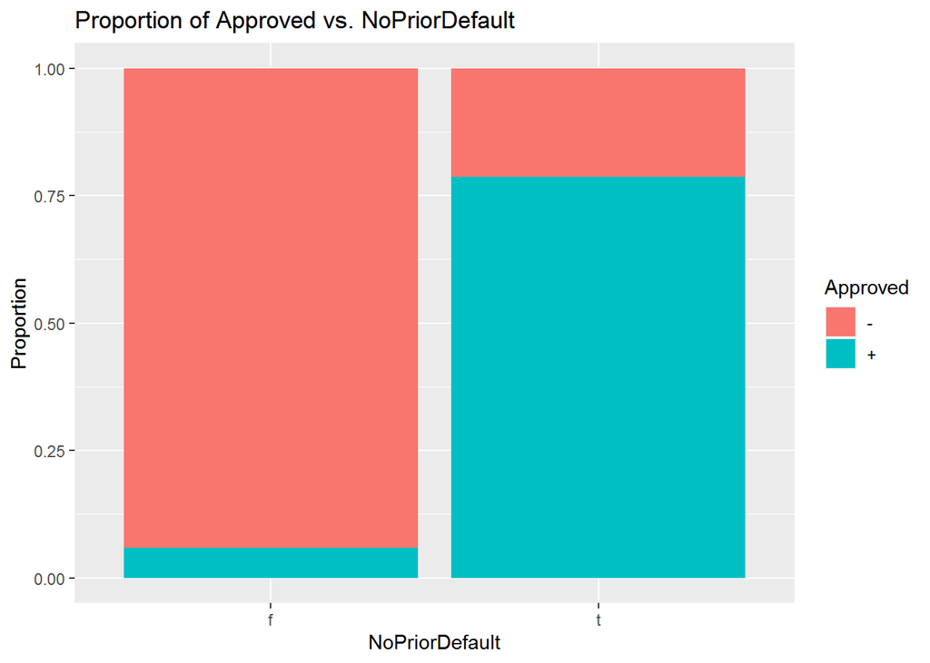

```r
library(ggplot2) # Load ggplot2 package

# Plot NoPriorDefault bar chart
df %>% ggplot(aes(x = NoPriorDefault, fill = Approved)) +
  geom_bar(stat = "count", position ="fill") +
  ggtitle("Proportion of Approved vs. NoPriorDefault") +
  labs(y = "Proportion")
```

Similarly, whether an applicant is employed or not seems to be a predictor, although not quite as much as NoPriorDefault.

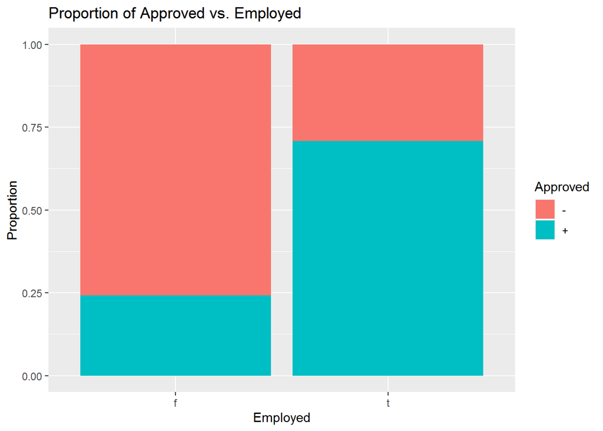

```r
# Plot Employed bar chart
df %>% ggplot(aes(x = Employed, fill = Approved)) +
  geom_bar(stat = "count", position ="fill") +
  ggtitle("Proportion of Approved vs. Employed") +
  labs(y = "Proportion")
```

### Continuous Variables

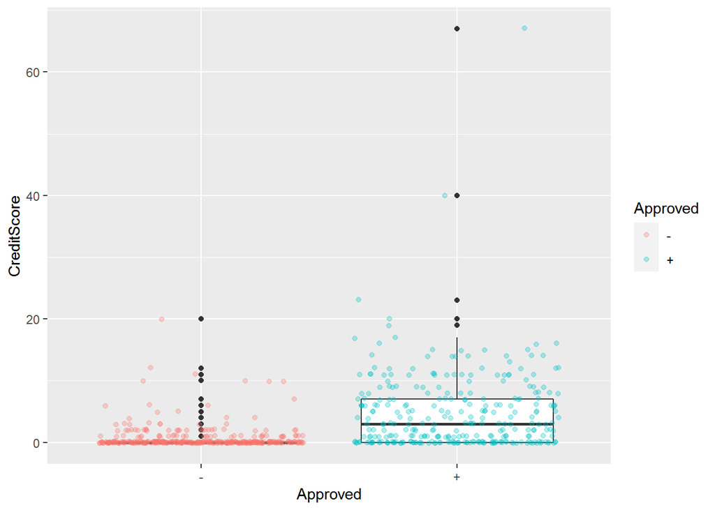

```r
# Plot CreditScore boxplot
cs_boxplot <- df %>% ggplot(aes(x = Approved, y = CreditScore)) +
  geom_boxplot() +
  geom_point(aes(col = Approved), position = position_jitter(width = 0.4, height = 0.15), alpha = 0.3)
cs_boxplot
```

```r
# Coerce CreditScore values greater than upper limit to equal limit
df$CreditScore[df$CreditScore > 20] <- 20
```

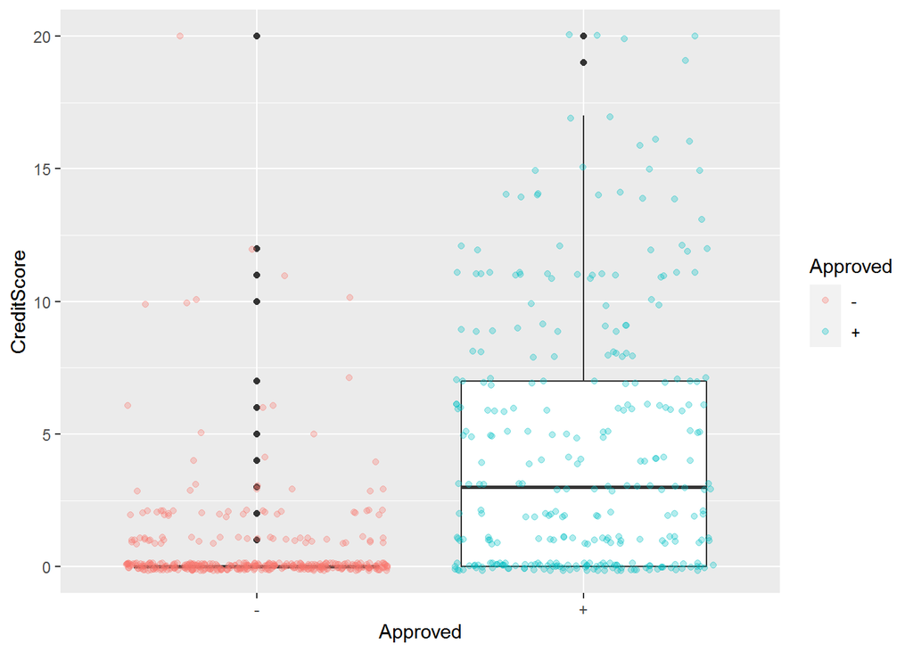

```r
cs_boxplot + coord_cartesian(ylim = c(0,20)) # Added y limits but unnecessary after data coercion.
```

To get another perspective on the distribution of this variable we can view the histogram. The data is heavily right-skewed owing to the large number of zero values in the data. This is an interesting phenomenon and something that might be easily explained with the right domain knowledge. Intuition tells us that if you have defaulted on a loan recently you can probably expect your credit score to crash. We can take a look using the NoPriorDefault variable to see if there is any correlation…

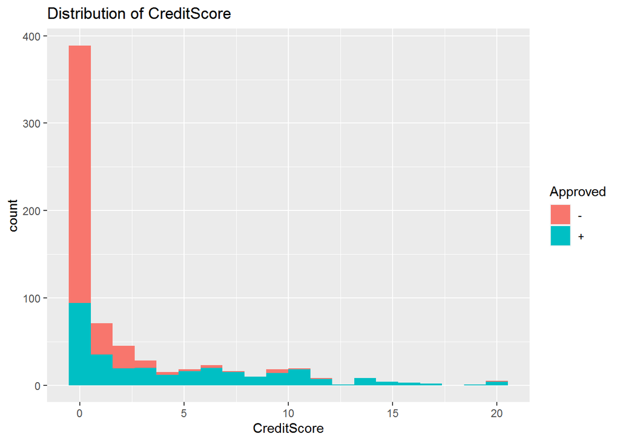

```r
# Plot CreditScore histogram
df %>% ggplot(aes(x = CreditScore, fill = Approved)) +
  geom_histogram(bins = 20) +
  ggtitle("Distribution of CreditScore")
```

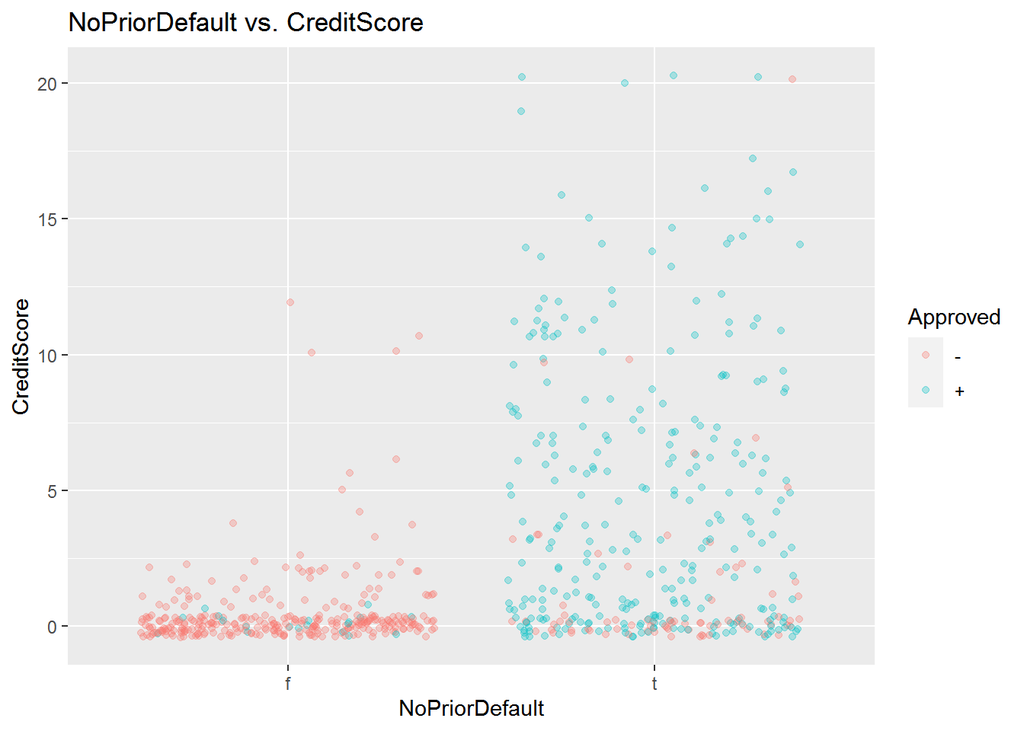

```r
# Plot NoPriorDefault vs. Credit Score
df %>% ggplot(aes(x = NoPriorDefault, y = CreditScore, col = Approved)) +
  geom_jitter(alpha = 0.3) +
  ggtitle("NoPriorDefault vs. CreditScore")
```

What we see tells us that most applicants who have had a prior default, also have a low credit score, which could indicate that the low credit score is as a result of the prior loan default. Makes sense. We would expect to see this link determined through any association rules generated on the data.

When analysing the distribution of the Income variable, we have a similar scenario in that a few outliers in the data skew the proportion of the plot and we’re unable to clearly make out the distributions in the data. So let’s see what we can do about those outliers…

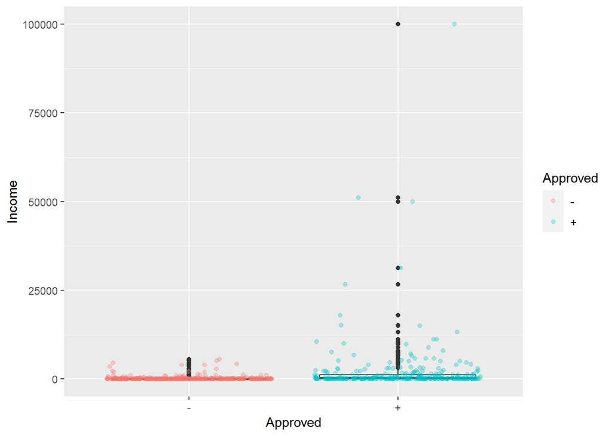

```r
# Plot Income boxplot
income_boxplot <- df %>% ggplot(aes(x = Approved, y = Income)) +
  geom_boxplot() +
  geom_point(aes(col = Approved), position = position_jitter(width = 0.4, height = 0.15), alpha = 0.3)
income_boxplot
```

```r
# Print the high earners
df %>% filter(Income > 25000) %>% as.data.frame()
```

```
##   Gender   Age  Debt MaritalStatus BankCustomer EducationLevel Ethnicity
## 1      b 33.17  1.04             u            g              r         h
## 2      b 34.17  1.54             u            g             cc         v
## 3      a 47.42  8.00             u            g              e        bb
## 4      a 18.75  7.50             u            g              q         v
## 5      b 17.50 22.00             l           gg             ff         o
##   YearsEmployed NoPriorDefault Employed CreditScore DriversLicense Citizen
## 1          6.50              t        f           0              t       g
## 2          1.54              t        t           1              t       g
## 3          6.50              t        t           6              f       g
## 4          2.71              t        t           5              f       g
## 5          0.00              f        f           0              t       p
##   ZipCode Income Approved
## 1   00164  31285        +
## 2   00520  50000        +
## 3   00375  51100        +
## 4   00000  26726        +
## 5   00450 100000        +
```

Income was just a working variable name given to this data column, with no units specified. We observe from the boxplot that most people’s Income is below 6000, so it is probably safe to assume that this is not an annual income if we assume the currency belongs to either GBP, EUR or USD. One particular instance stands out and that is one for which Income is 100000. 17 and a half years of age and not employed… with such a high income? Smells like the offspring of an oligarch to me. Either that or a self-employed sportstar. Anyway, in this cas it seems safe to remove this instance as on outlier.

```r
df <- df %>% filter(Income != 100000) # Remove outlier
```

For the remaining outliers, those where Income > 25000, we want to retain the information. Therefore, while acknowledging that it may be possible for incomes that high, we’ll coerce the values to an upper limit of 25000 to bring them more in-line with the distribution of the other points. This should reduce any effect these outliers may have on a learning scheme while retaining a correct classification.

```r
# Coerce other outliers to upper limit, this time with dplyr!
df <- df %>% mutate(Income = replace(Income, Income > 25000, 25000))
```

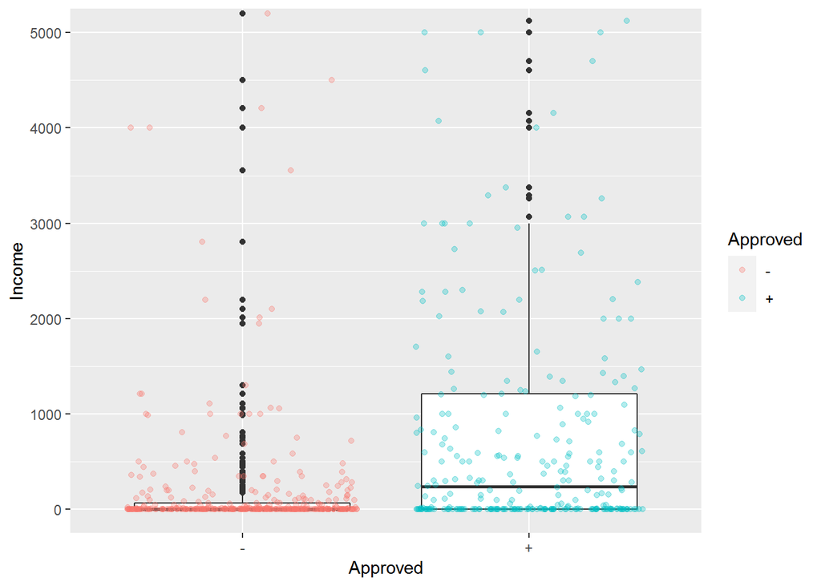

It’s worth checking how Income relates to the attributes Employed and YearsEmployed to see if the data reflects what we might expect - that is, having an income typically means an applicant is employed and that the more years an applicant has been employed the greater their income.

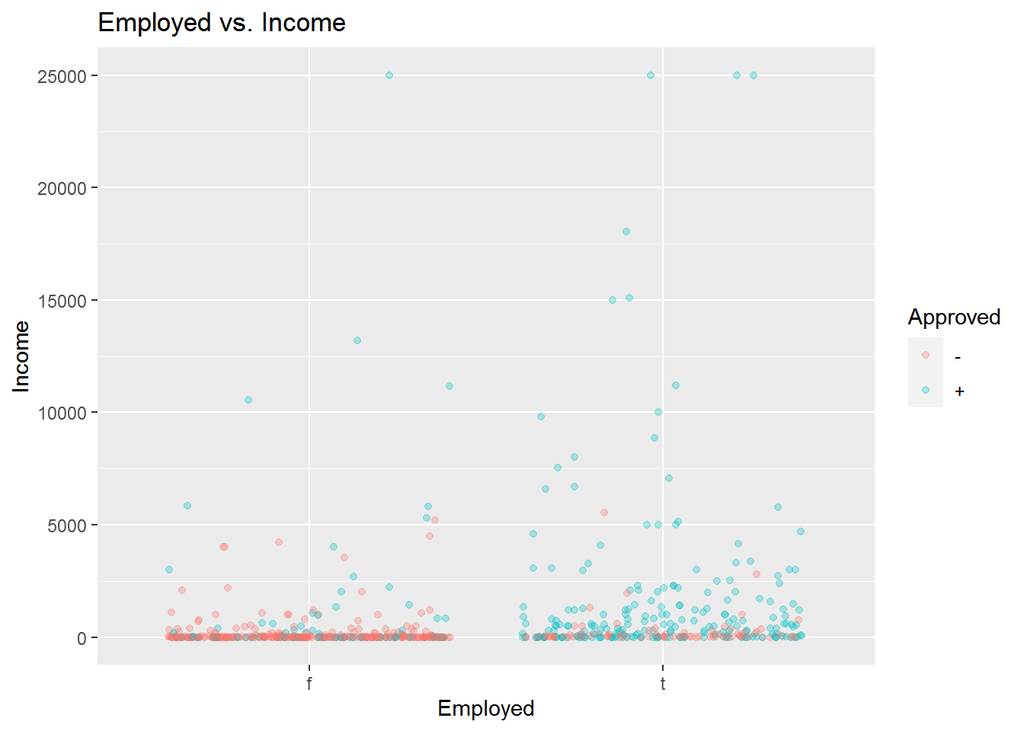

```r
# Plot Employed vs. Income
df %>% ggplot(aes(x = Employed, y = Income, col = Approved)) +
  geom_jitter(alpha = 0.3) +
  ggtitle("Employed vs. Income")
```

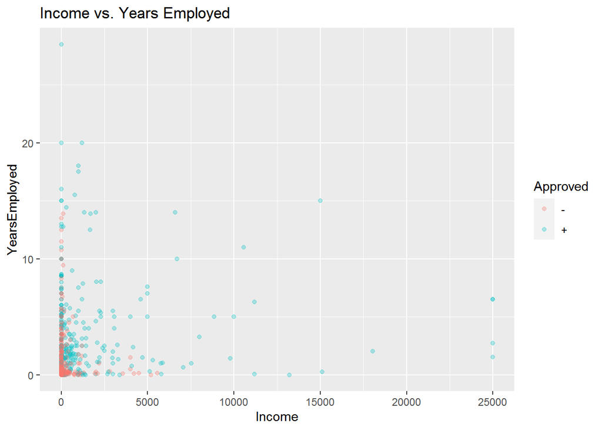

```r
# Plot Income vs. Years Employed
df %>% ggplot(aes(x = Income, y = YearsEmployed, col = Approved)) +
  geom_point(alpha = 0.3) +
  ggtitle("Income vs. Years Employed")
```

From the Employed vs. Income plot we can confirm that most applicants that are unemployed have zero income. However, what’s odd is that there are a number of applicants who **are** employed but have zero income. It seems unlikely that there are many people in slavery out there applying for credit cards, so you might expect that there should be another explanation for these observations. It could be that if data is not entered on the application under Income, the value defaults to zero, which we’d obviously like to investigate further if we were the owners of this data as it may reduce performance of any machine learning methods. However, for the remainder of this analysis we’ll assume the data is correct.

From the Income vs. Years Employed plot we observe similarly baffling behaviour. There’s not an obvious positive correlation as you might expect, and there seems to be a large number of applicants employed for many years with zero income. There is either something seriously worth investigating about these datapoints, or the working variables we’ve assumed for this data are probably not completely fit for purpose (probably the latter). Interpreting YearsEmployed as total previous years employment might be more suitable. For now, we’ll just move on.

A last look at the histogram for Income shows that most rejected applicants have a low income, and that the zero values skew the data to the right.

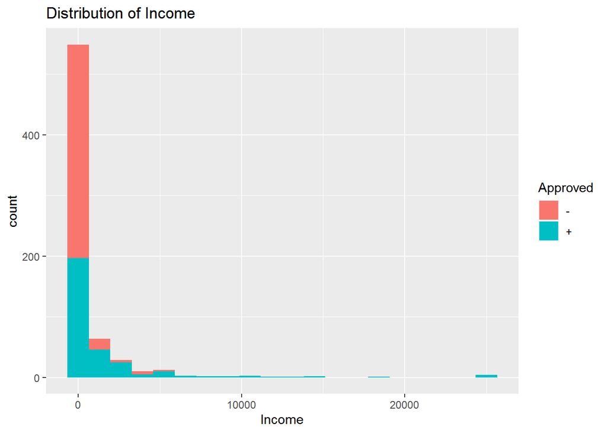

```r
# Plot Income histogram
df %>% ggplot(aes(x = Income, fill = Approved)) +
  geom_histogram(bins = 20) +
  ggtitle("Distribution of Income")
```

A histogram of the Debt attribute again shows a right skew of the data, and a fairly even distribution of classes throughout, suggesting debt will not be as good a predictor as the previous two continuous variables.

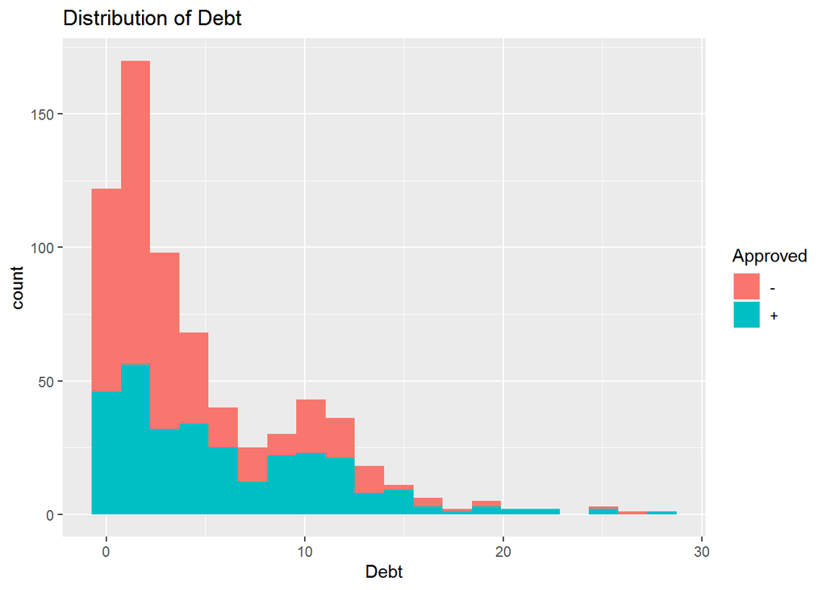

```r
# Plot Debt Histogram
df %>% ggplot(aes(x = Debt, fill = Approved)) +
  geom_histogram(bins = 20) +
  ggtitle("Distribution of Debt")
```

Finally let’s look at age. Age shows no obvious indication of predicted class, probably because it is not usually a factor considered in the approval decision. The data is right skewed, with most applications coming from those in the 20-40 bracket. This probably reflects the period in most peoples’ lives where they are willing to take more financial risks with starting a business or a family. Older people are likely to be more comfortable with their financial assets in later life so would be less likely to apply. It may serve the analysis to discretise Age so we’ll create a new column later on.

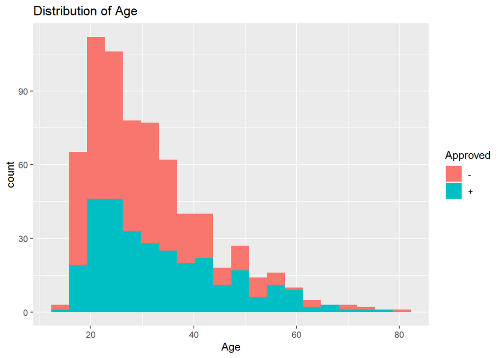

```r
# Plot age histogram
df %>% ggplot(aes(x = Age, fill = Approved)) +
  geom_histogram(bins = 20) +
  ggtitle("Distribution of Age")
```

### Nominal Variables

While inspecting the data I noticed that the columns MaritalStatus and BankCustomer always seemed to have matching pairs. Let’s check that by plotting them against each other.

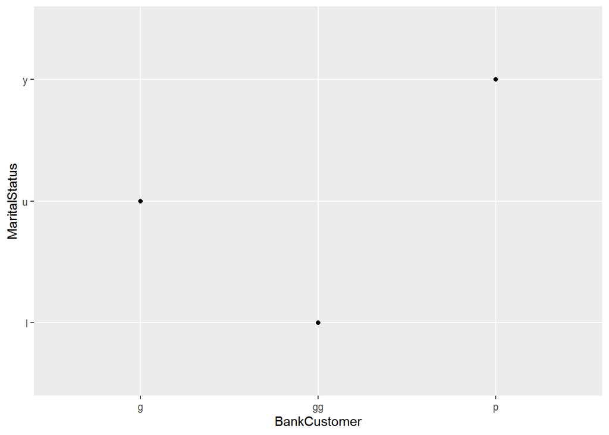

```r
# Plot MaritalStatus vs. Bank Customer
df %>% drop_na(MaritalStatus, BankCustomer) %>%
  ggplot(aes(x = BankCustomer, y = MaritalStatus)) + geom_point()
```

The points are perfectly correlated, with three points representing the only pairs seen across the whole dataset. Again our working names come into dispute, as there’s no good reason why the applicants marital status should correlate with whether the applicant is a customer of the bank or not. One of these columns gives us absolutely no new information about the dataset if the other one is present, and keeping it in would bias any machine learning models in favour of information from the duplicated column. Therefore, we’ll delete BankCustomer.

```r
df <- df %>% select(-BankCustomer) # Remove BankCustomer column
```

Upon inspection of the MaritalStatus column, there appears to be an under-represented class “l”, which won’t be able to tell us any information about the dataset that would be generalisable to new applicants. In the case of levels with very low counts, it’s useful to remove them and drop the levels from the factor.

```r
df <- df %>% filter(MaritalStatus != "l")         # Filter df to remove MaritalStatus matching "l"
df$MaritalStatus <- droplevels(df$MaritalStatus)  # Drop unused levels
summary(df$MaritalStatus)
```

```
##   u   y
## 519 163
```

We notice a similar scenario in the citizen column, a category “p” occuring just once in the dataset. Let’s filter out that instance as well.

```r
summary(df$Citizen)
```

```
##   g   p   s
## 625   1  56
```

```r
df <- df %>% filter(Citizen != "p")   # Filter df to remove Citizen matching "p"
df$Citizen <- droplevels(df$Citizen)  # Drop unused levels
summary(df$Citizen)
```

```
##   g   s
## 625  56
```

Viewing a plot of `Ethnicity` we see that a majority of applicants sit in category “v” and that the class distribution roughly represents the 45%:55% split inherent in the dataset. We would hope to see this behaviour as application approval decisions should not be biased by ethnic discrimination. However, the categories “h” and “z” display approval bias, whereas the category “ff” shows a high percentage of rejections. It could be worth digging a little deeper into the data to see whether other factors could be influencing these outcomes, that appear to be discriminatory at first glance.

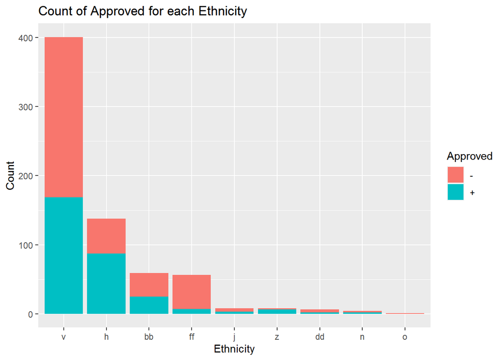

```r
# Plot Ethnicity bar chart: count
df %>% count(Ethnicity, Approved) %>%
  ggplot(aes(x = fct_reorder(Ethnicity, desc(n)), y = n, fill = Approved)) + geom_col() +
  labs(x = "Ethnicity", y = "Count") +
  ggtitle("Count of Approved for each Ethnicity")
```

First let’s view the `EducationLevel` of the whole population.

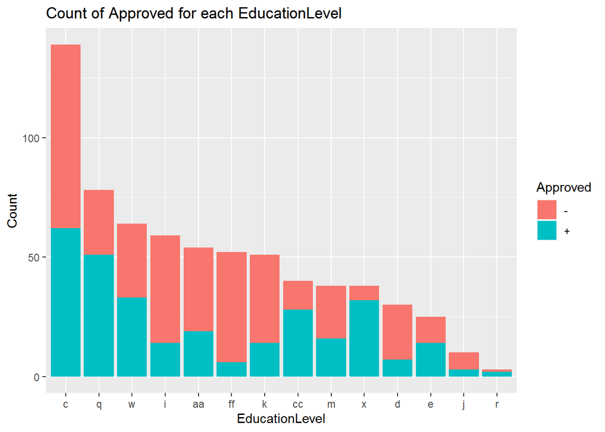

```r
df %>% count(EducationLevel, Approved) %>%
  ggplot(aes(x = fct_reorder(EducationLevel, desc(n)), y = n, fill = Approved)) + geom_col() +
  labs(x = "EducationLevel", y = "Count") +
  ggtitle("Count of Approved for each EducationLevel")
```

Now let’s view the `EducationLevel` for the `Ethnicity` categories described earlier. It seems to be that the Ethnicity “ff” correlates with the Education Level “ff” highly, so that may be a link. Further investigation is needed but we won’t go into that now.

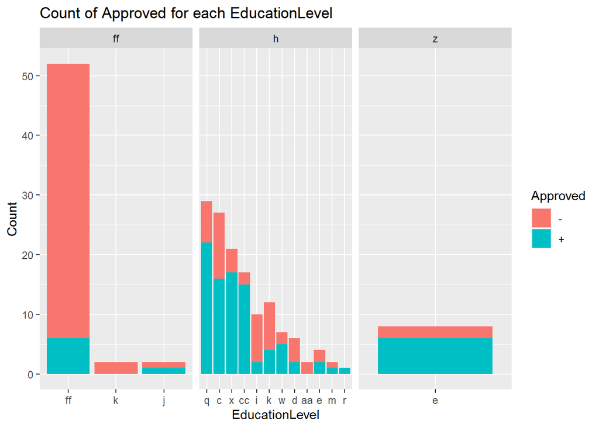

```r
# Plot EducationLevel for subset
df %>% filter(Ethnicity %in% c("ff", "h", "z")) %>%
  count(EducationLevel, Ethnicity, Approved) %>%
  ggplot(aes(x = fct_reorder(EducationLevel, desc(n)), y = n, fill = Approved)) + geom_col() +
  facet_wrap(~Ethnicity, scales = "free_x") +
  labs(x = "EducationLevel", y = "Count") +
  ggtitle("Count of Approved for each EducationLevel")
```

## Feature Engineering

Let’s create a new column CreditRating, a factor with five levels created by placing CreditScore values into equal bins.

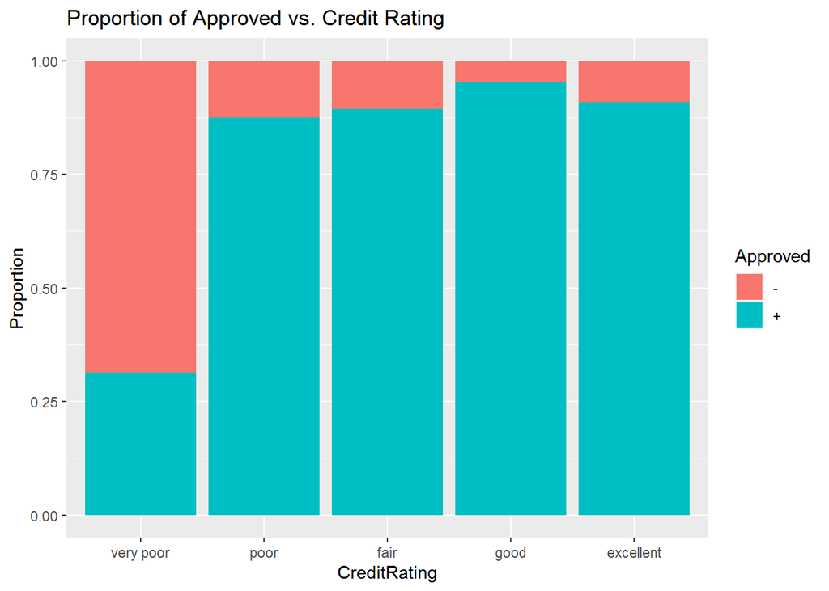

```r
# Discretise Credit Score (new column CreditRating)
cs_labels <- c("very poor", "poor", "fair", "good", "excellent")
df <- df %>% mutate(CreditRating = cut(CreditScore, seq(0, 20, 4), right = FALSE))
levels(df$CreditRating) <- cs_labels
df$CreditRating[is.na(df$CreditRating)] <- "excellent" # Because values equal to 20 were coerced to NA

# And plot
cr_plot <- df %>% ggplot(aes(x = CreditRating, fill = Approved))
cr_plot + geom_bar(position = "fill") +
  ggtitle("Proportion of Approved vs. Credit Rating") +
  labs(y = "Proportion")
```

Let’s create a new column AgeBracket with variable bin size.

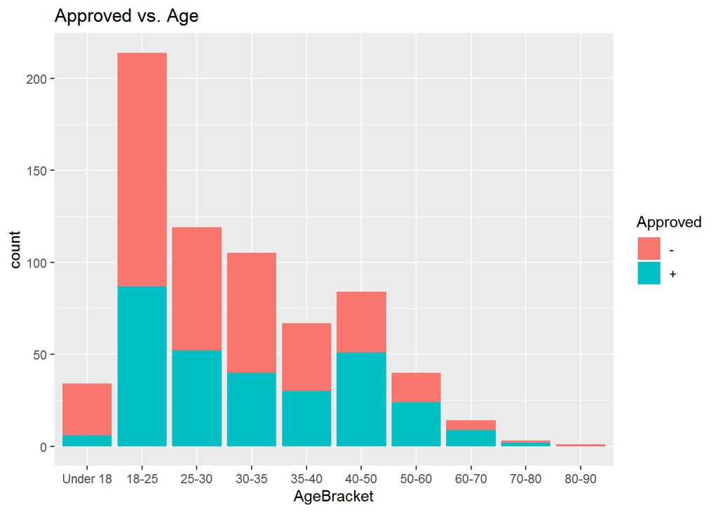

```r
age_labels <- c("Under 18", "18-25", "25-30", "30-35", "35-40", "40-50",
                "50-60", "60-70", "70-80", "80-90")
df <- df %>% mutate(AgeBracket = cut(Age, c(0, 18, 25, 30, 35, seq(40, 90, 10)), right = FALSE))
levels(df$AgeBracket) <- age_labels

# And plot
age_plot <- df %>% ggplot(aes(x = AgeBracket, fill = Approved))
age_plot + geom_bar(stat = "count") +
  ggtitle("Approved vs. Age")
```

## Summary of Changes

A number of changes have been made in the cleaning and wrangling process. Here is a summary:

1. Four instances evaluated to represent incomplete applications were removed.
2. Missing values in the `Age` attribute were imputed with the mean.
3. Missing values in the `Education Level`, `Ethnicity`, `ZipCode` and `Gender` columns were imputed with the most frequent category (mode).
4. The column `CreditScore` was assumed to have limits [0, 20] and values outside these ranges were coerced to the limits.
5. Outlier with `Income > 100000` removed.
6. Instances with values of `Income > 25000` were coerced to 25000.
7. `BankCustomer` column was removed as it was perfectly correlated with `MarriageStatus` and hence added no new information about the dataset.
8. Removed instances that created categories with very low counts in the `MaritalStatus` and `Citizen` columns and dropped the unused levels.
9. `CreditRating` column created by by placing `CreditScore` values into five equal bins.
10. `AgeBracket` column created by placing `Age` values into ten bins of varying size.

Now that the data has been cleaned we can save it for import into Weka.

```r
# Reorder so class is last
df <- df[ ,c(names(df)[names(df) != "Approved"], "Approved")]

# Write clean data frame to a CSV
write_csv(df, "data/credit_cleaned.csv")
```

## Machine Learning Model Spot-check

To spot-check a variety of machine learning methods I will be using the Weka Explorer. [Weka is a GUI machine learning workbench](https://www.cs.waikato.ac.nz/ml/weka/index.html) that allows the user to work through the machine learning process without having to write code. It can be used as a good first step for getting familiarised with a dataset and a sense for which learning schemes are likely to offer good enough performance to solve your problem. In this project I will be sticking to Weka for the modelling, but in future projects I plan to demonstrate similar methods using the `caret` package (**C**lassification **a**nd **re**gression **t**raining) in R, authored by Max Kuhn.

### Introduction to Weka Explorer

I want to quickly introduce the Weka Explorer and the various views I will be using for the modelling.

[figure not shown]

This view is the Preprocess tab. Here is where you can:

- Load your data
- View all the attributes
- Remove attributes
- Apply pre-processing filters to the data
- Visualise the univariate distributions of attributes coloured by the class (default)
- Get information about selected attributes, such as missing, unique and distinct values, and min, max, mean and standard deviation of values for numeric attributes and count frequencies for categorical variables.

Clicking the visualise all button shows all univariate visualisations at once, see below.

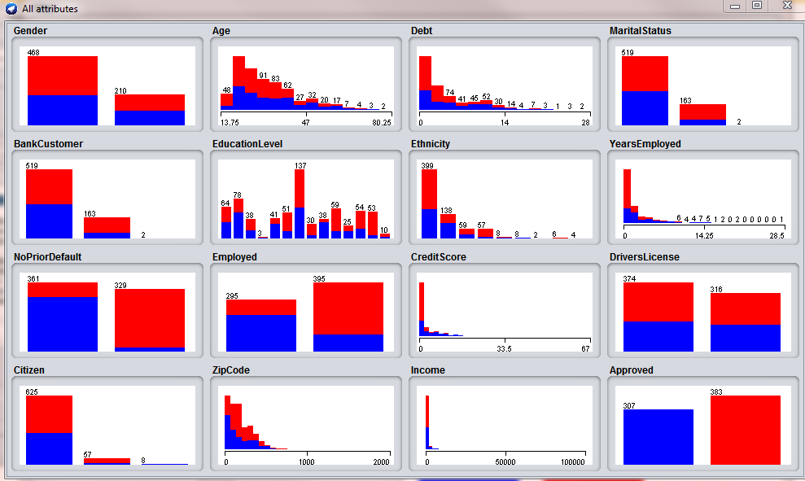

Univariate Attribute Plots

The Visualise tab below, allows you to browse the pairwise plots for each attribute. Clicking a plot will enlarge it in a separate window for a better view. Again, the points are coloured by class as the default, but this can be changed to any other nominal attribute and even numeric attributes for which it applies a colour scale.

[figure not shown]

Visualize Tab

[figure not shown]

Multivariate Scatter Plot

The final tab I’ll introduce for now, is the Classify tab which is used to apply supervised learning models to the data. Here is where you can:

- Choose your algorithm
- Set the test options (cross-validation with 10 folds is set as default)
- Run the algorithm and view the output from the model
- Cycle through previous model outputs

[figure not shown]

Classify Tab

By right clicking on model outputs you also have the option to view classification errors, visualise the tree if a decision tree was generated as part of the algorithm, and view curves such as the ROC and cost curves.

[figure not shown]

Classification errors

[figure not shown]

Decision Tree

[figure not shown]

Cost Curve

Weka is a powerful tool for spot-checking different algorithms quickly on datasets that fit into memory. It can also be utilised by purpose built tools via a Java API. All open-source too! And this is just the Explorer, you also have the Experimenter, KnowledgeFlow , Workbench and Command Line Interface sides to the tool.

### Models

Back to top

As explained in the earlier section The Problem, deciding whether to approve a credit card application or not is a binary classification problem (given a set of features). Some commonly used techniques for binary classification in credit risk evaluation are Logistic Regression, Support Vector Machines, Artificial Neural Networks and Classification and Regression Trees (CART). These are the subset of algorithms that I’ll use to create models and I’ll be evaluating the performance between them: so let’s briefly introduce them…

#### Logistic Regression

[Logistic Regression](https://en.wikipedia.org/wiki/Logistic_regression) is a technique to estimate a logistic function to model a binary dependent variable (the class). The estimated function is a linear combination of one or more independent variables known as predictors, which can be either categorical or continuous. It is a special case of the generalised linear model (GLM) and thus is analogous to linear regression. However, it is based on different assumptions, the key ones being:

- The conditional distribution $y | x$ is a Bernoulli distribution (usually illustrated with the classic coin toss head/tail outcome) rather than a Gaussian (Normal) distribution, because the dependent variable is binary.
- The predicted values are probabilities and are therefore restricted to (0, 1), because logistic regression predicts the probability of particular outcomes rather than the outcomes themselves. [^2]

It’s important to note from the second point that by itself the model does not perform statistical classification, but it can be used to make a classifier by specifying a cutoff value, with probability greater than the value defined as a “success” (and less than defined as a failure, or the other class).

Since the estimated function is linear it generates a linear decision boundary between the data points which tends to generalise well to new unseen data. Part of the reason is that the effects of noise are limited and the model does not overfit to training data. A linear model is also fairly straightforward to interpret, as combination of feature values weighted by the model coefficients. However, if there are non-linear relationships in the data it is unlikely that Logistic Regression will model them well.

#### Support Vector Machines

A support vector machine (SVM) is a blend of linear modelling and instance-based learning that constructs a hyperplane, or set of hyperplanes, in a high-dimensional space to separate instances into two classes, making it a binary linear classifier. It works by selecting a small number of critical boundary instances called *support vectors* from each class and building a linear discriminant function that separates them as widely as possible i.e. one that maximises the *margin*. The number of critical boundary instances chosen depends on the *gamma* parameter.

In a two-dimensional space a hyperplane is simply a line dividing the plane in two parts where on either side lay each class. An original problem may be stated in a finite-dimensional space, but it often happens that the sets to discriminate are not linearly separable in that space. Therefore the technique maps the original space to a much higher-dimensional space to attempt to make the separation easier. It does this using what is called the *kernel trick*. SVMs can transcend the limitations of linear boundaries by making it practical to include extra nonlinear terms in the function, making it possible to form quadratic, cubic and higher-order decision boundaries.

#### Artificial Neural Networks

An artificial neural network (ANN) is a computing system that is based on a collection of connected units or nodes called *artificial neurons*, which loosely model the neurons in a biological brain. It is not an algorithm in itself, but a framework for many different machine learning algorithms to work together and process complex data inputs. An ANN forms by connecting the output of certain neurons, (or nodes), to the input of other neurons (via edges), forming a directed, weighted graph. The weights, as well as the functions that compute the activation (the functions at each node), are modified in the learning process.

The class of feedforward ANN, (meaning connections between nodes do not form a cycle so information only flows forward), being used in this analysis is the Multilayer Perceptron (MLP), a classifier that uses backpropagation to learn a multi-layer perceptron to classify instances. Backpropagation is a method to calculate a gradient that is needed in the calculation of weights to be used in the network. It’s called backpropagation since an error is computed at the output and distributed backwards throughout the network’s layers. A commonly used algorithm to find the set of weights that minimise the error is gradient descent, with backpropagation then being used to calculate the steepest descent direction.

The MLP consists of three or more layers (an input, output and one or more hidden layers) of non-linearly activating nodes. This is what distinguishes it from the perceptron, which is a linear classifier, as MLPs can classify data that is not linearly separable. Also, whereas the perceptron performs binary classification, an MLP neuron is free to perform either classification or regression depending upon its activation function. Since MLPs are fully connected, each node in one layer connects with a certain weight $w_{ij}$ to every node in the following layer.

An advantage of the Multilayer Perceptron and neural networks in general is that the model continually updates with each new set of classified instances. In other words it is continually learning and is not just restricted to what was learned from the training set.

#### Classification and Regression Trees (CART)

CART refers to decision tree algorithms that can be used for classification or regression predictive modelling problems. A tree model is called a classification or regression tree depending on whether the target variable takes a discrete set of values or a continuous value (respectively). CART can introduce multivariate tests, where tests are constructed using more than one attribute. They also include techniques and methods for handling nominal attributes and dealing with missing values. Trees with multivariate tests are often more accurate and smaller than univariate trees, but they take much longer to generate and are more difficult to interpret.

Creating a CART model involves selecting input attributes and split points on those attributes until a suitable tree is constructed - a divide-and-conquer approach. The selection of which attribute to use and specific split point chosen is determined by a greedy algorithm that minimises a cost function, which occurs recursively until a stopping criterion has been reached. A greedy algorithm means the very best split point is chosen each time. The most common stopping procedure is to use a minimum count on the number of training instances assigned to each leaf node. If the count is less than some minimum then the split is not accepted and the node is taken as the final leaf node.

To avoid overfitting and create simpler trees that are easier to interpret, you can prune the tree using either a pre or post-pruning method. Prepruning involves trying to decide during the tree-building process when to stop developing subtrees. Post-pruning finds a model that fits the data well, and then prunes back to a simpler description that also fits the data. Post-pruning is usually preferred over prepruning as there can sometimes be combinations of attributes that form powerful predictors that wouldn’t be found unless the full tree is formed.

### Method

So now, enough discussion of the tools and the algorithms - it’s time to do some machine learning! I want to get an understanding of the effects that the various preprocessing steps have on the overall performance of the different algorithms, and therefore I’ll be comparing performance at the following five stages:

| Code | Description |
| --- | --- |
| D1 | The raw data, with just the ZipCode attribute removed. |
| D2 | The cleaned data, with original numeric Age and CreditScore columns (AgeBracket and CreditRating removed) |
| D3 | The cleaned data, with the new categorical AgeBracket and CreditRating columns (Age and CreditScore removed) |
| D4 | The cleaned data with only financial attributes (NoPriorDefault, Employed, YearsEmployed, CreditScore, Income, Debt) |
| D5 | The cleaned data with financial attributes with categorical CreditRating (numerical CreditScore removed) |

The subset of attributes under “financial attributes” are the following:

- Income
- Debt
- CreditScore
- Employed
- YearsEmployed
- NoPriorDefault

Consequently, attributes were evaluated for selection based on their gain ratio and these six attributes were ranked highest.

#### Evaluation Metrics

The metrics that I’ll be using to compare the performance are the following:

- The classification accuracy (CA) (% of instances that were correctly predicted by the model)
- The root mean squared area (RMSE)
- The number of False Positives (FP) and False Negatives (FN) from the confusion matrix
- The Area Under Curve (AUC) of the ROC curve (a plot of the True Positive rate vs False Positive Rate)

To decide what is most important we can refer back to the problem definition in The Problem section. We want a high classification accuracy and we also want to reduce the false positives as a defaulting customer costs more than profit gained from a missed customer.

#### Setting a Baseline

It is important to set a baseline for which to evaluate the models against. This is typically done using a very simplistic method for which our models should absolutely perform better than to be considered. The simple method we’ll use in this case is the ZeroR algorithm which simply predicts the majority class. In this case the majority class will be “-”, meaning all applications are rejected - not usually a great business strategy. The ZeroR classifier should reflect the class distribution mentioned in The Data since it is a binary class. We’ll perform the algorithm once for the raw data and once for the cleaned data, since some instances have been removed which may have affected the distribution.

| Set | CA | RMSE | FP | FN | AUC |
| --- | --- | --- | --- | --- | --- |
| Raw Data | 55.5072 % | 0.497 | 0 | 307 | 0.494 |
| Clean Data | 55.8003 % | 0.4933 | 0 | 301 | 0.499 |

There is not much change between the raw data and clean data in terms of classification accuracy, which is expected because only 1.3% of the instances were removed from the data - there was never going to be any dramatic changes. So these are the targets to beat - if our chosen algorithms are going to add any value to the business in terms of selecting the right applicants, then they must at least do better than this simple classifier.

#### Preparing the Data

In order to evaluate model performance properly, we should be testing its prediction accuracy on unseen data - that is, data that has not been used to train the model. A simple method for this is to split the available instances into a training set and a test set. It is usually desired to want a greater proportion of the instances used to train the model, which is therefore why we see train test splits of 66%:34%, or 75%:25%. When splitting the data, a stratified sampling method can be used to keep the underlying class distribution in the data as this will lead to better results.

Cross-validation is a different method for preparing the data, and it is the method that I will be using for building the models. In *k*-fold cross-validation, the original sample is randomly partitioned into k equal sized subsamples. A subsample is retained as the test set, and all remaining subsamples are used for the training set. This process is repeated *k* times until each of the subsamples has been used exactly once as the test set. The *k* error estimates are then averaged to yield an overall error estimate. Cross-validation helps to get the most out of the dataset and prevent overfitting, as all instances are used in both training and observation.

I’ll be using 10-fold cross-validation, as it is the standard method in practical terms. Finally, it is important to set the seed when sampling for the cross-validation folds. This ensures the chosen folds are reproducible for building models using each algorithm and allows us to make a true comparison. Not setting the seed would mean the estimates will be sensitive to the variance in the sample data.

### The Results

A model was built using each of the four algorithms specified in the section Models and the various dataset changes listed under the section Method. The test harness for this initial comparison will be the Classification Accuracy and the number of False Positives.

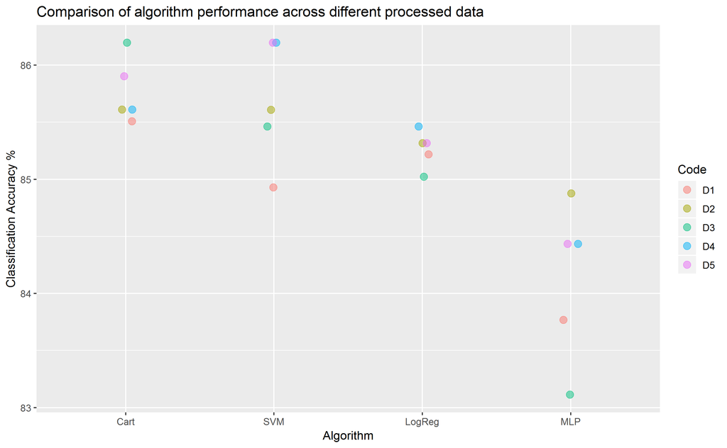

The classification accuracy on the raw data (**D1**) is generally the lowest out of the five different datasets, which suggests our data engineering had some effect on improving performance. The instances where this is not true are for the Logistic Regression and Multilayer Perceptron algorithms, where the cleaned data with two discretised variables (**D3**) actually has the worst accuracy. This suggests that these two algorithms don’t respond well to discretised attributes, and prefer their original continuous values.

All algorithms have a very reasonable classification accuracy between 83%-87% which significantly improves on the baseline case of 55%. The CART algorithm has a consistently high accuracy across the datasets, followed closely by SVM which with the subset of attributes matches the best performance of CART. We’ll keep this in mind as we evaluate the second test harness: false positives.

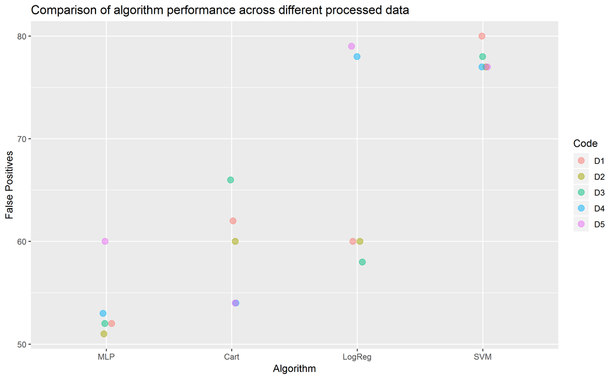

SVM consistently classifies a large number of Type 1 Errors (false positives), which is not a good outcome in the real life business case as the classifier will be approving loans to applicants likely to default. MLP has the best performance in terms of reducing the number of false positives, particularly for the **D2** case which also corresponds to that algorithm’s best classification accuracy - this makes it a contender for selection for tuning. The CART algorithm performs well in the cases of **D4** and **D5** but not so well in the case of **D3**. **D5** matches with good classification accuracy so the CART algorithm under these conditions is also a good contender for improvement beyond the spot-check. Taking a subset of attributes (**D4, D5**) results in a significant increase in the amount of false positives for the Logistic Regression algorithm, so would be advised against in this case.

### Conclusion and Next Steps

Some interesting behaviours were observed in this spot-check of machine learning algorithms. Further testing on a variety of datasets is required to determine whether this behaviour is characteristic to the changes made. If we were moving forward in the algorithm selection for this problem, we would probably select the Multilayer Perceptron on the clean data and non-discretised attributes (**D2**), and the CART algorithm on the clean data with a subset of attributes and discretised attributes (**D5**).

Suggested next steps to improve performance would be:

- Try transforming or rescaling the continuous attributes to lift performance.
- Try improving performance by tuning available parameters, using grid search, optimisation or other methods.
- If business costs are known for each outcome, provide a cost matrix and evaluate cost-senstivie classification.
- Use ensemble methods or boosting.

Before taking any of these steps, its worth considering if the current performance is good enough for solving the business problem. Any further improvements are likely to have a cost so the motivation for improvements needs to be clear.

### Suggested improvements for next project

- Improve and refine my workflow to create concise output more efficiently.
- Focus on a summary of the problem and the results, and not a verbose justification for each step.
- Deploy more intelligent methods for dealing with missing values and outliers
- Explore different data transofrmations and scaling on model performance
- Spot-check a few more popular machine learning algorithms under standard configurations that will give them a fighting chance in the comparisons
- Use a more sophisticated tool such as the Weka Explorer or Caret in R for comparing algorithm performance
[^1]: http://rstudio-pubs-static.s3.amazonaws.com/73039_9946de135c0a49daa7a0a9eda4a67a72.html#ensemble-the-models
[^2]: https://en.wikipedia.org/wiki/Logistic_regression#Logistic_regression_vs._other_approaches